# HW2_Molotkov

## 1. Import libraries

```r
library(ggplot2)
library(DESeq2)
library(apeglm)
library(ggrepel)
library(dplyr)
library(org.Mm.eg.db)
library(fgsea)
```

## 2. Obtain the count data

```r
countFiles <- list.files('analysis/featureCounts/')
countFiles <- sapply(X = countFiles, USE.NAMES = F, FUN = function(name) {
  paste('analysis/featureCounts/', name, '/', name, '.fc.txt', sep = '')
})

counts <- lapply(countFiles, function(countsFile) {
  read.table(countsFile, sep="\t", header=1, row.names = 1, stringsAsFactors = F)
})

counts <- lapply(counts, function(countsTable) countsTable[, ncol(countsTable), drop=F])
counts <- do.call(cbind, counts)
colnames(counts) <- c('GSM3215429', 'GSM3215430', 'GSM3215431',
                      'GSM3215432', 'GSM3215433', 'GSM3215434')

row.names(counts) <- gsub('(ENSMUSG\\d+)\\..*', '\\1', row.names(counts))

head(counts)
```

```
##                    GSM3215429 GSM3215430 GSM3215431 GSM3215432 GSM3215433
## ENSMUSG00000102693          0          0          0          0          0
## ENSMUSG00000064842          0          0          0          0          0
## ENSMUSG00000051951          0          0          0          3          0
## ENSMUSG00000102851          0          0          0          0          0
## ENSMUSG00000103377          0          0          0          2          1
## ENSMUSG00000104017          0          0          0          1          0
##                    GSM3215434
## ENSMUSG00000102693          0
## ENSMUSG00000064842          0
## ENSMUSG00000051951          0
## ENSMUSG00000102851          0
## ENSMUSG00000103377          0
## ENSMUSG00000104017          0
```

## 3. Add the info about samples

File names do not contain needed info, so I looked it up in the NCBI

```r
coldata <- data.frame(
  gsm=c('GSM3215429', 'GSM3215430', 'GSM3215431',
        'GSM3215432', 'GSM3215433', 'GSM3215434'),
  foam=c('foam', 'foam', 'foam',
         'non_foam', 'non_foam', 'non_foam'),
  row.names=c('GSM3215429', 'GSM3215430', 'GSM3215431',
              'GSM3215432', 'GSM3215433', 'GSM3215434')
)

coldata
```

```
##                   gsm     foam
## GSM3215429 GSM3215429     foam
## GSM3215430 GSM3215430     foam
## GSM3215431 GSM3215431     foam
## GSM3215432 GSM3215432 non_foam
## GSM3215433 GSM3215433 non_foam
## GSM3215434 GSM3215434 non_foam
```

## 4. Perform DESeq

Only leave genes that have more than 10 reads across samples.

```r
dds <- DESeqDataSetFromMatrix(countData = counts[rowSums(counts) > 10, ],
                              colData = coldata,
                              design= ~ foam)
dds <- DESeq(dds)
```

## 5. Plot PCA after VST

The plot below shows that after performing the VST foam vs non-foam samples are divided along the first principal component very well.

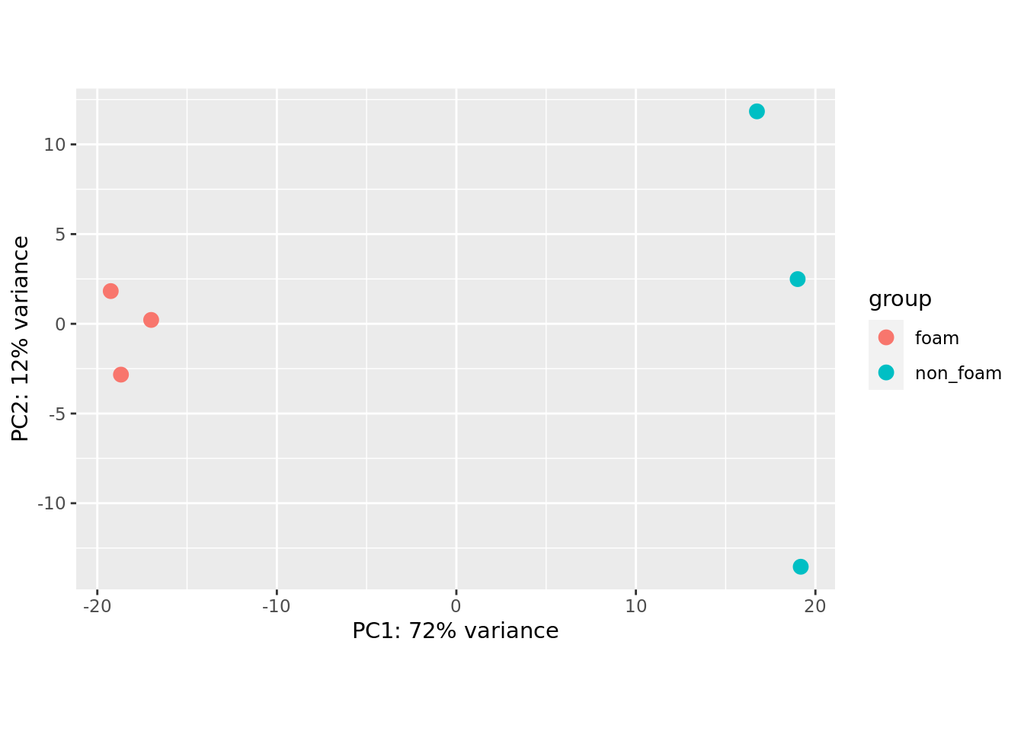

```r
vst <- varianceStabilizingTransformation(dds)
plotPCA(vst, intgroup=c("foam"))
```

## 6. Shirnk lfc and present the Volcano Plot

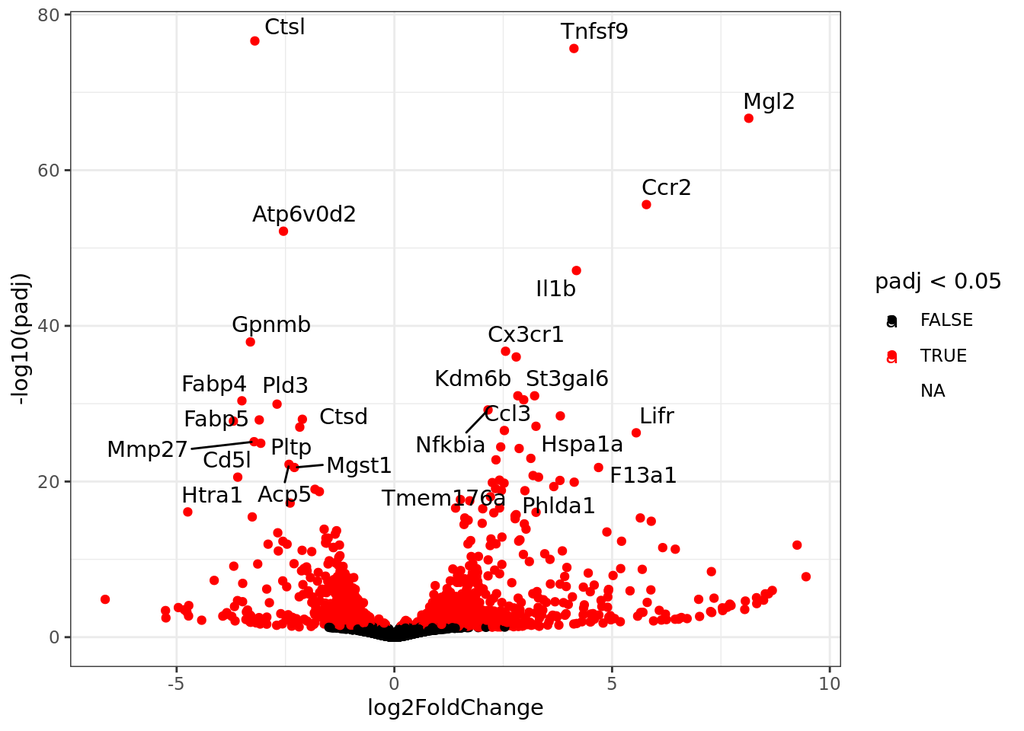

```r
res <- lfcShrink(dds, coef="foam_non_foam_vs_foam", type="apeglm")

#keytypes(org.Mm.eg.db)
res$Gene.symbol <- mapIds(org.Mm.eg.db, rownames(res), column="SYMBOL", keytype = "ENSEMBL")

res <- as.data.frame(res)
ggplot(res, aes(x=log2FoldChange, y=-log10(padj), color=padj < 0.05)) +
  geom_point() + theme_bw() + scale_color_manual(values=c("black", "red")) +
  geom_text_repel(data=res %>% dplyr::filter(padj < 1e-20), aes(label=Gene.symbol, color=NULL))
```

## 7. Pathway analysis

We get top-300 most significantly differentially expressed genes.

```r
top300_genes <- head(res[order(res$padj), ], 300)$Gene.symbol
cat(top300_genes, "\n", file = "top_genes.txt")
```

Then we run them through MSigDB. Since our macrophages differ in that foamy macrophages are associated with lipid processing and non-foamy with inflammation, we would expect to see those two functions come up in the results.

This is exactly what we get from MSigDB: most of the overlapped gene sets are related to those functions. For example, HALLMARK_TNFA_SIGNALING_VIA_NFKB (adjusted q-score 1.02e-54), GOBP_DEFENSE_RESPONSE (adjusted q-score 4e-48), GOBP_INFLAMMATORY_RESPONSE (adjusted q-score 2.23e-40), GOBP_RESPONSE_TO_LIPID (adjusted q-score 4.35e-35).

```r
tnfa_signaling <- read.csv('./HW2/tnfa_signaling.txt',
                           skip = 2, header = F)[,1]

def_response <- read.csv('./HW2/defence_response.txt',
                         skip = 2, header = F)[,1]

infl_response <- read.csv('./HW2/inflammatory_response.txt',
                          skip = 2, header = F)[,1]

lipid_response <- read.csv('./HW2/response_to_lipid.txt',
                           skip = 2, header = F)[,1]

res <- res[!is.na(res$padj), ]
```

As we can see from the histograms below, for each gene set adjusted p-values are skewed towards 0. Although, the skewness is the most significant for HALLMARK_TNFA_SIGNALING_VIA_NFKB.

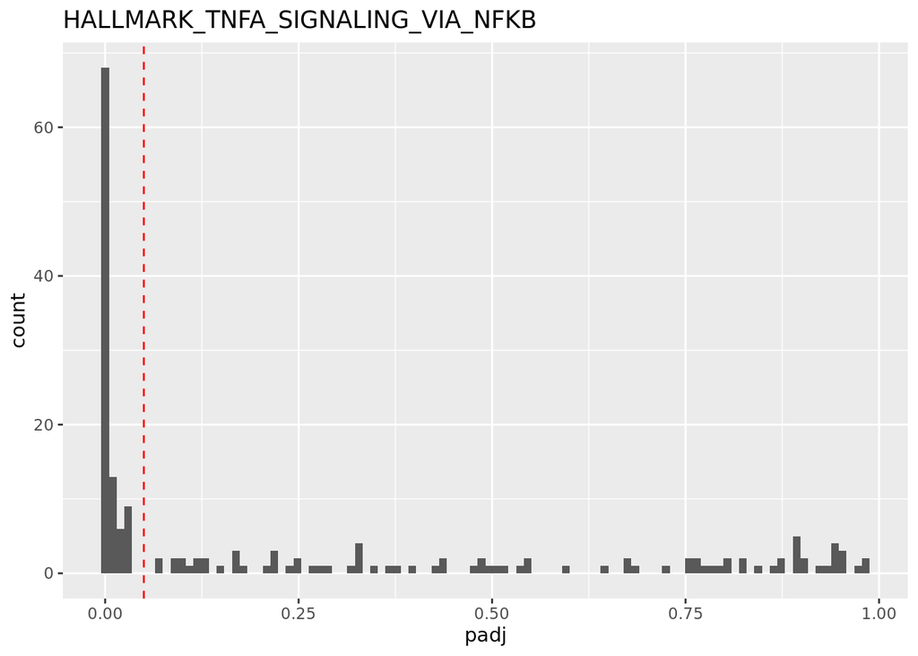

```r
ggplot(res[toupper(res$Gene.symbol) %in% tnfa_signaling, ], aes(x=padj)) +
  geom_histogram(bins = 100) +
  geom_vline(xintercept = 0.05, color='red', linetype='dashed') +
  ggtitle('HALLMARK_TNFA_SIGNALING_VIA_NFKB')
```

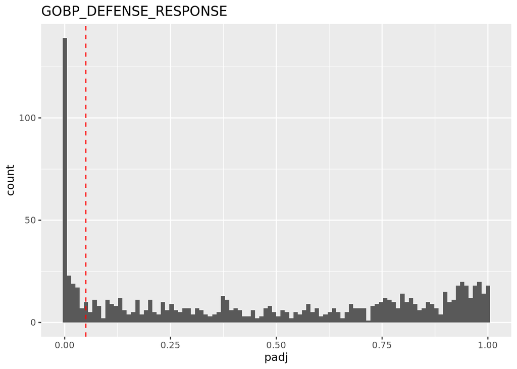

```r
ggplot(res[toupper(res$Gene.symbol) %in% def_response, ], aes(x=padj)) +
  geom_histogram(bins = 100) +
  geom_vline(xintercept = 0.05, color='red', linetype='dashed') +
  ggtitle('GOBP_DEFENSE_RESPONSE')
```

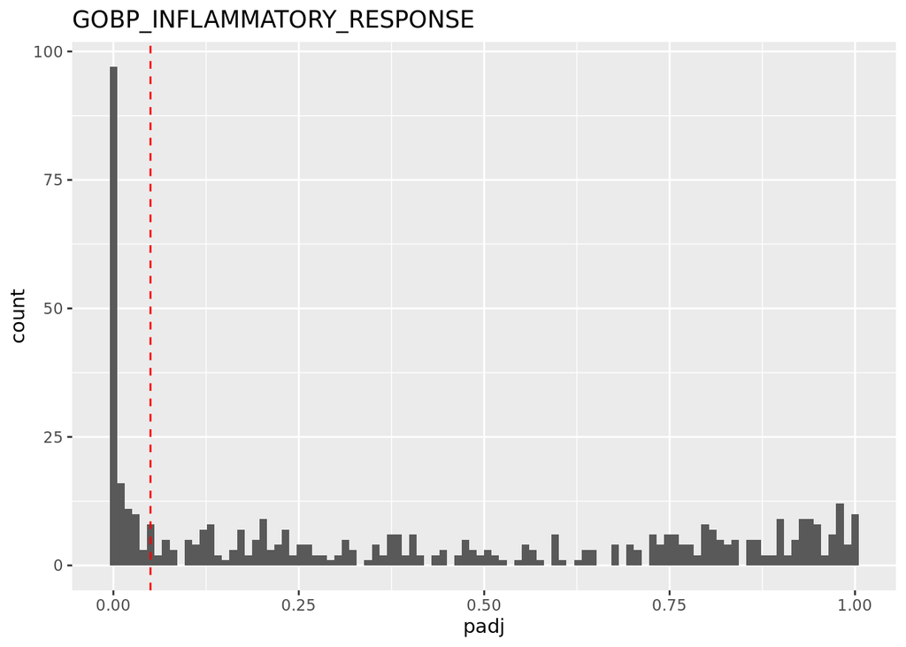

```r
ggplot(res[toupper(res$Gene.symbol) %in% infl_response, ], aes(x=padj)) +
  geom_histogram(bins = 100) +
  geom_vline(xintercept = 0.05, color='red', linetype='dashed') +
  ggtitle('GOBP_INFLAMMATORY_RESPONSE')
```

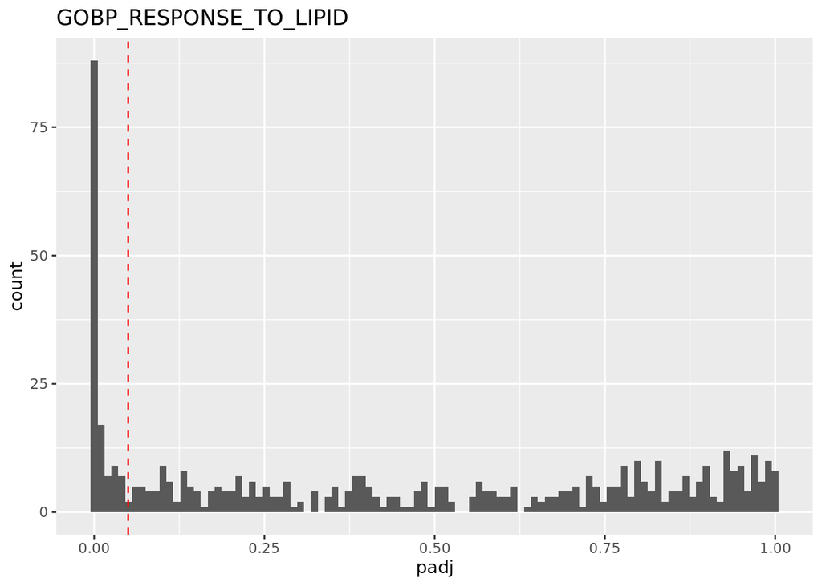

```r
ggplot(res[toupper(res$Gene.symbol) %in% lipid_response, ], aes(x=padj)) +
  geom_histogram(bins = 100) +
  geom_vline(xintercept = 0.05, color='red', linetype='dashed') +
  ggtitle('GOBP_RESPONSE_TO_LIPID')
```